# Bellabeat Case Study

Vishnu

2024-11-02

# ANALYSIS

This analysis aims to explore the Fitbit data for various health metrics, with an emphasis on average weekly steps, activity minutes, sleep minutes, and heart rate per user. By comparing users’ metrics to established baselines, we can gain insights into their general activity and wellness levels.

# Step 1: Set the Working Directory

To ensure R reads from the correct directory, we set the working directory to the folder where the data files are stored.

## 1.1 Set working directory

```r
setwd("/cloud/project/Bellabeat Case Study/Data Sources")
```

## 1.2 Verify the current working directory

```r
getwd()
```

```
## [1] "/cloud/project/Bellabeat Case Study/Data Sources"
```

# Step 2: Load the Data

In this step, we load the required data files: nhis_2016_summary.csv, final_weekly_summary.csv, and who_baseline_summary.csv. These files contain information on user activity, sleep, and heart rate metrics.

## 2.1 Load necessary data files

```r
nhis_data <- read.csv("nhis_2016_summary.csv", header = TRUE)
weekly_summary <- read.csv("final_weekly_summary.csv", header = TRUE)
who_baseline <- read.csv("who_baseline_summary.csv", header = TRUE)
```

## 2.2 Preview the data

Displaying the first few rows of each dataset to verify the structure and contents.

```r
head(nhis_data)
```

```
##   avg_nhis_vigorous_minutes avg_nhis_moderate_minutes
## 1                    201.07                    235.75
##   avg_nhis_sleep_duration_minutes
## 1                          418.84
```

```r
head(weekly_summary)
```

```
##           Id year week total_weekly_steps total_weekly_calories
## 1 2026352035 2016   16              31548                 10341
## 2 2026352035 2016   17              40236                 11012
## 3 2026352035 2016   18              47741                 11552
## 4 2026352035 2016   19              33938                  7627
## 5 2347167796 2016   15              83382                 15368
## 6 2347167796 2016   16              66214                 14993
##   total_weekly_vigorous_minutes total_weekly_moderate_minutes
## 1                             0                             0
## 2                             0                             0
## 3                             0                             0
## 4                             0                             0
## 5                           132                           244
## 6                            87                           161
##   total_weekly_time_in_bed total_weekly_minutes_asleep
```

[output cut: 34 more lines]

```r
head(who_baseline)
```

```
##           Id year week total_weekly_vigorous_minutes
## 1 2026352035 2016   16                             0
## 2 2026352035 2016   17                             0
## 3 2026352035 2016   18                             0
## 4 2026352035 2016   19                             0
## 5 2347167796 2016   15                           132
## 6 2347167796 2016   16                            87
##   total_weekly_moderate_minutes total_weekly_minutes_asleep
## 1                             0                        2915
## 2                             0                        3145
## 3                             0                        3079
## 4                             0                        2408
## 5                           244                        1364
## 6                           161                        2760
##   baseline_activity_minutes baseline_sleep_minutes activity_baseline_status
## 1                       150                   2940  Below Activity Baseline
## 2                       150                   2940  Below Activity Baseline
## 3                       150                   2940  Below Activity Baseline
## 4                       150                   2940  Below Activity Baseline
## 5                       150                   2940  Meets Activity Baseline
## 6                       150                   2940  Meets Activity Baseline
##   sleep_baseline_status
## 1  Below Sleep Baseline
## 2  Meets Sleep Baseline
## 3  Meets Sleep Baseline
## 4  Below Sleep Baseline
## 5  Below Sleep Baseline
## 6  Below Sleep Baseline
```

# Step 3: Data Wrangling and Preparation for Visualization

This step involves calculating key metrics for each user, such as their average weekly activity, sleep, and heart rate metrics, and comparing these metrics to NHIS and WHO baselines where applicable.

## 3.1 Load Required Libraries

```r
install.packages("tidyverse")
install.packages("tidyr")
library(tidyverse)
library(tidyr)
library(dplyr)
```

## 3.2 Calculate Mean Values for Key Metrics

Using the weekly_summary data, we calculate average weekly metrics for steps, vigorous activity, moderate activity, sleep, and heart rate.

```r
weekly_summary_summary <- weekly_summary %>%
  summarise(
    avg_weekly_steps = mean(total_weekly_steps, na.rm = TRUE),
    avg_weekly_vigorous_minutes = mean(total_weekly_vigorous_minutes, na.rm = TRUE),
    avg_weekly_moderate_minutes = mean(total_weekly_moderate_minutes, na.rm = TRUE),
    avg_weekly_minutes_asleep = mean(total_weekly_minutes_asleep, na.rm = TRUE),
    avg_weekly_heart_rate = mean(average_weekly_heart_rate, na.rm = TRUE)
  )
```

## 3.3 Display the summarized results

```r
weekly_summary_summary
```

```
##   avg_weekly_steps avg_weekly_vigorous_minutes avg_weekly_moderate_minutes
## 1         48657.35                    134.5652                    87.30435
##   avg_weekly_minutes_asleep avg_weekly_heart_rate
## 1                  1885.065              76.92109
```

## 3.4 Calculate Average Vigorous and Moderate Activity Minutes per User

```r
vigorous_moderate_summary <- weekly_summary %>%
  group_by(Id) %>%
  summarise(
    avg_vigorous_minutes = mean(total_weekly_vigorous_minutes, na.rm = TRUE),
    avg_moderate_minutes = mean(total_weekly_moderate_minutes, na.rm = TRUE)
  )
```

## 3.4.1 Reshape Data for Plotting

We reshape the data into long format to create a combined bar plot for vigorous and moderate activity minutes.

```r
vigorous_moderate_long <- vigorous_moderate_summary %>%
  pivot_longer(
    cols = c(avg_vigorous_minutes, avg_moderate_minutes),
    names_to = "Activity_Type",
    values_to = "Average_Minutes"
  )
```

# Step 4: Create Visualizations for Key Metrics

We visualize key metrics to uncover trends and compare users’ activity and sleep patterns against baseline recommendations. We’ll start by creating individual plots for each key metric to show general trends. Here are the visualizations we’ll make:

```
- **Weekly Steps**: A bar plot showing average weekly steps per user.
- **Weekly Vigorous and Moderate Activity Minutes**: A bar plot comparing average weekly vigorous and moderate activity minutes.
- **Weekly Sleep Minutes**: A bar plot of average weekly sleep minutes, including NHIS baseline comparison.
- **Weekly Heart Rate**: A line plot of average weekly heart rate per user.
```

### Load ggplot2 for Plotting

```r
library(ggplot2)
```

# 4.1: Average Weekly Steps Per User

This plot shows the average weekly steps for each user, highlighting individual differences in daily activity.

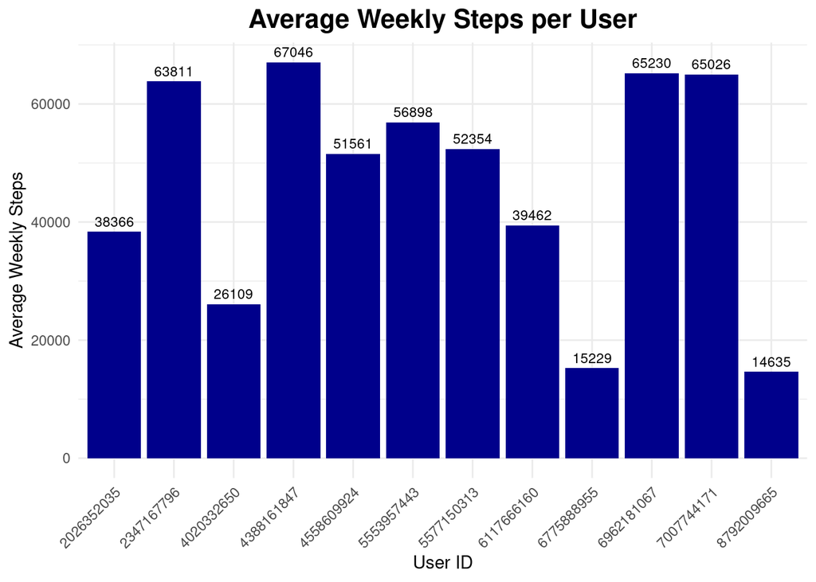

```r
ggplot(weekly_summary, aes(x = factor(Id), y = total_weekly_steps)) +
  geom_bar(stat = "summary", fun = "mean", fill = "darkblue") +
  geom_text(
    stat = "summary",
    fun = "mean",
    aes(label = round(after_stat(y), 0)),
    vjust = -0.5,
    color = "black",
    size = 3
  ) +
  labs(
    title = "Average Weekly Steps per User",
    x = "User ID",
    y = "Average Weekly Steps"
  ) +
  theme_minimal() +
  theme(
    plot.title = element_text(hjust = 0.5, size = 16, face = "bold"),
    axis.text.x = element_text(angle = 45, hjust = 1)
  )
```

# 4.2: Average Weekly Vigorous and Moderate Activity Minutes per User

This combined bar plot compares users’ average vigorous and moderate activity levels, showcasing their engagement in different activity intensities.

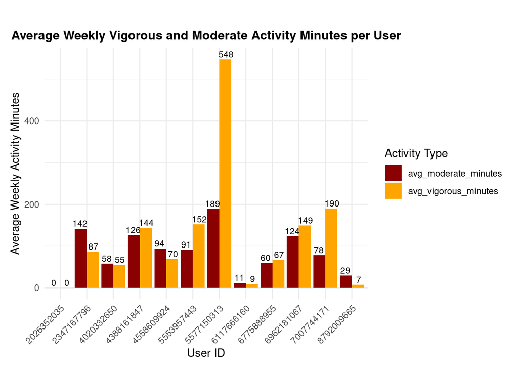

```r
ggplot(vigorous_moderate_long, aes(x = factor(Id), y = Average_Minutes, fill = Activity_Type)) +
    geom_bar(stat = "identity", position = "dodge") +
    scale_fill_manual(values = c("darkred", "orange")) +  # Set custom colors
    geom_text(
        aes(label = round(Average_Minutes, 0)),
        position = position_dodge(width = 1),
        vjust = -0.3,  # Adjust this value to move labels higher above bars
        size = 3,
        color = "black"
    ) +
    labs(
        title = "Average Weekly Vigorous and Moderate Activity Minutes per User",
        x = "User ID",
        y = "Average Weekly Activity Minutes",
        fill = "Activity Type"
    ) +
    theme_minimal() +
    theme(
        plot.title = element_text(hjust = 0.5, size = 12, face = "bold"),  # Reduce font size and center the title
        axis.text.x = element_text(angle = 45, hjust = 1),
        plot.margin = margin(t = 30, r = 10, b = 10, l = 10)  # Increase top margin to ensure title fits within plot area
    )
```

# Step 4.3: Average Weekly Sleep Minutes per User

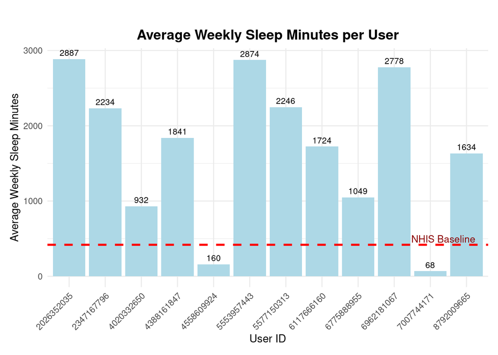

```r
nhis_sleep_baseline <- 418.84

aggregated_sleep_data <- weekly_summary %>%
  group_by(Id) %>%
  summarize(avg_weekly_minutes_asleep = mean(total_weekly_minutes_asleep))

ggplot(aggregated_sleep_data, aes(x = factor(Id), y = avg_weekly_minutes_asleep)) +
    geom_bar(stat = "identity", fill = "lightblue") +
    geom_hline(yintercept = nhis_sleep_baseline, color = "red", linetype = "dashed", linewidth = 1) +
    geom_text(
        aes(label = round(avg_weekly_minutes_asleep, 0)),
        vjust = -0.5, # Moves label above the bar
        size = 3, # Reduce size for better readability
        color = "black"
    ) +
    # Add annotation near the NHIS baseline line
    annotate(
        "text", x = Inf, y = nhis_sleep_baseline, label = "NHIS Baseline",
        color = "darkred", hjust = 1.2, vjust = -0.3, size = 3.5) +
    labs(
        title = "Average Weekly Sleep Minutes per User",
        x = "User ID",
        y = "Average Weekly Sleep Minutes"
    ) +
    theme_minimal() +
    theme(
        plot.title = element_text(hjust = 0.5, size = 14, face = "bold"),
        axis.text.x = element_text(angle = 45, hjust = 1),
        plot.margin = margin(t = 30, r = 10, b = 10, l = 10) # Increased top margin
    )
```

# Step 4.4: Average Weekly Heart Rate per User

The line plot below shows average weekly heart rate per user, providing insight into users’ cardiovascular health.

### Create aggregated_heart_rate_data

```r
aggregated_heart_rate_data <- weekly_summary %>%
    group_by(Id) %>%
    summarise(avg_weekly_heart_rate = mean(average_weekly_heart_rate, na.rm = TRUE))

aggregated_heart_rate_data <- aggregated_heart_rate_data[order(aggregated_heart_rate_data$Id), ]
```

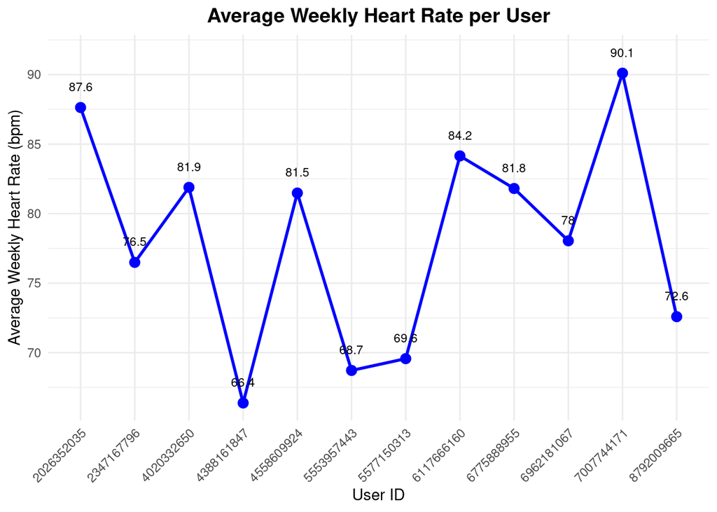

```r
ggplot(aggregated_heart_rate_data, aes(x = factor(Id), y = avg_weekly_heart_rate, group = 1)) +
    geom_line(color = "blue", linewidth = 1) +  # Changed 'size' to 'linewidth'
    geom_point(color = "blue", size = 3) +
    geom_text(
        aes(label = round(avg_weekly_heart_rate, 1)),
        nudge_y = 1.5,  # Adjust label position slightly above the line
        color = "black",
        size = 3
    ) +
    labs(
        title = "Average Weekly Heart Rate per User",
        x = "User ID",
        y = "Average Weekly Heart Rate (bpm)"
    ) +
    theme_minimal() +
    theme(
        plot.title = element_text(hjust = 0.5, size = 14, face = "bold"),
        axis.text.x = element_text(angle = 45, hjust = 1)
    )
```